# Clase3

ObedEs

4/18/2021

# Lectura de Archivos

Para este trabajo utilizaremos los datos utilizados en la clase anterior. Nos enfocaremos en la comparación entre bebedores y no bebedores.

```r
setwd("~/Asistencias/Clase2/Data")
hers <- read.table("hersdata.csv",sep = ",",header = T)
#Existen otras funciones como read.csv,read.csv2 o read.delim (sep= “,” “;” “\” respectivamente)
```

# Exploración de los datos

Para observar los pocos registros de nuestros datos podemos utilizar head() para los primeros registros o tail() para los últimos.

```r
#el parametro n es el numero registros que nos va a mostrar
head(hers,n = 6)
```

```
##                HT age           raceth nonwhite smoking drinkany exercise
## 1         placebo  70 African American      yes      no       no       no
## 2         placebo  62 African American      yes      no       no       no
## 3 hormone therapy  69            White       no      no       no       no
## 4         placebo  64            White       no     yes      yes       no
## 5         placebo  65            White       no      no       no       no
## 6 hormone therapy  68 African American      yes      no      yes       no
##                physact globrat poorfair medcond htnmeds statins diabetes
## 1     much more active    good       no       0     yes     yes       no
## 2     much less active    good       no       1     yes      no       no
## 3      about as active    good       no       0     yes      no      yes
## 4     much less active    good       no       1     yes      no       no
## 5 somewhat less active    good       no       0      no      no       no
## 6      about as active    good       no       0      no      no       no
##   dmpills insulin weight   BMI waist   WHR glucose weight1  BMI1 waist1  WHR1
## 1      no      no   73.8 23.69  96.0 0.932      84    73.6 23.63   93.0 0.912
## 2      no      no   70.9 28.62  93.0 0.964     111    73.4 28.89   95.0 0.964
## 3      no      no  102.0 42.51 110.2 0.782     114    96.1 40.73  103.0 0.774
## 4      no      no   64.4 24.39  87.0 0.877      94    58.6 22.52   77.0 0.802
## 5      no      no   57.9 21.90  77.0 0.794     101    58.9 22.28   76.5 0.757
## 6      no      no   60.9 29.05  96.0 1.000     116    57.7 27.52   86.0 0.910
##   glucose1 tchol   LDL HDL  TG tchol1  LDL1 HDL1 TG1 SBP DBP age10
## 1       94   189 122.4  52  73    201 137.6   48  77 138  78   7.0
## 2       78   307 241.6  44 107    216 150.6   48  87 118  70   6.2
## 3       98   254 166.2  57 154    254 156.0   66 160 134  78   6.9
## 4       93   204 116.2  56 159    207 122.6   57 137 152  72   6.4
## 5       92   214 150.6  42 107    235 172.2   35 139 175  95   6.5
## 6      115   212 137.8  52 111    202 126.6   53 112 174  98   6.8
```

```r
#tail(hers)
```

Para observar las dimensiones de nuestros datos podemos utilizar las funciones dim() o nrow() y ncol().

```r
dim(hers)
```

```
## [1] 2763   37
```

```r
#numero de registros
nrow(hers)
```

```
## [1] 2763
```

```r
#numero de caracterisiticas
ncol(hers)
```

```
## [1] 37
```

Podemos utilizar la función table() para contabilizar cuántos registros de cada clase tenemos.

```r
table(hers$drinkany)
```

```
##
##        no  yes
##    2 1680 1081
```

# Separación de los datos

Generamos 2 conjuntos de datos uno para bebedores y otro para no bebedores (ignoraremos los registros que no tengan informacion). R permite indexar vectores con otros vectores así que obtendremos y ordenar y separar fácilmente datos

```r
drinkanyData.yes<-hers[hers$drinkany=="yes",]
dim(drinkanyData.yes)
```

```
## [1] 1081   37
```

```r
#La diferencia entre usar which retorna los indices que cumplen la condicion y el otro es un vector booleano
drinkanyData.no<-hers[which(hers$drinkany=="no"),]
dim(drinkanyData.no)
```

```
## [1] 1680   37
```

Otras funciones utiles son sort y order que permiten ordenar un lista de elementos sort devuelve un vector ordenado de los valores (sin contar NA) de la lista y order el índice de los valores ordenados El siguiente ejemplo ordena los datos por edad

```r
#para que sort devuelva el indice del valor y poder utilizarlo para ordenar un dataframe se utiliza el parametro index.return=T
orden<-sort(drinkanyData.yes$age,index.return=T)$ix
drinkanyData.yes<-drinkanyData.yes[orden,]
head(drinkanyData.yes[,1:6])
```

```
##                   HT age           raceth nonwhite smoking drinkany
## 400          placebo  44            White       no      no      yes
## 778          placebo  45 African American      yes     yes      yes
## 2689         placebo  45 African American      yes     yes      yes
## 586  hormone therapy  46 African American      yes     yes      yes
## 960  hormone therapy  46            White       no     yes      yes
## 1164 hormone therapy  46            White       no      no      yes
```

```r
orden<-order(drinkanyData.no$age)
drinkanyData.no<-drinkanyData.no[orden,]
head(drinkanyData.no[,1:6])
```

```
##                   HT age           raceth nonwhite smoking drinkany
## 2687         placebo  45            White       no     yes       no
## 839  hormone therapy  46 African American      yes      no       no
## 1526         placebo  46            White       no     yes       no
## 2717         placebo  47            White       no      no       no
## 97           placebo  48            White       no      no       no
## 850  hormone therapy  48            White       no      no       no
```

# Estadistica descriptiva

### Moda,media, mediana (medidas de tendencia central )

Calcularemos la media, moda y mediana de Triglicéridos(TG) para observar si hay diferencia entre bebedores y no bebedores

```r
#Eliminamos los valores nulos para no tener errores
drinkanyData.yes<-na.omit(drinkanyData.yes)
drinkanyData.no<-na.omit(drinkanyData.no)
media<-mean(drinkanyData.yes$TG)
#R no tiene una funcion para calcular la moda pero se puede calcular con table y which
modaT<-data.frame(table(drinkanyData.yes$TG))
moda<-modaT[which.max(modaT$Freq),1]
mediana<-median(drinkanyData.yes$TG)
MMMyes<-c(media=media,moda=moda,mediana=mediana)

media<-mean(drinkanyData.no$TG)
modaT<-data.frame(table(drinkanyData.no$TG))
moda<-modaT[which.max(modaT$Freq),1]
mediana<-median(drinkanyData.no$TG)
MMMno<-c(media=media,moda=moda,mediana=mediana)
```

```r
dt<-data.frame(MMMyes,MMMno)
dt
```

```
##           MMMyes    MMMno
## media   158.9304 169.5164
## moda     48.0000  71.0000
## mediana 147.0000 162.0000
```

Como se puede observar existen diferencias en ambos, principalmente un pequeño desplazamiento en la distribución de los datos. Intentemos observar un poco más la distribución de los datos de nuestro conjunto.

### Cuantiles

Los Cuantiles nos permiten dividir nuestros datos de tal manera que cada que todas las partes tengan la misma cantidad de datos y permiten ver la distribución de nuestros datos.Los más utilizados son los cuartiles,deciles y percentiles y R tiene una función para calcular todos,quantile()

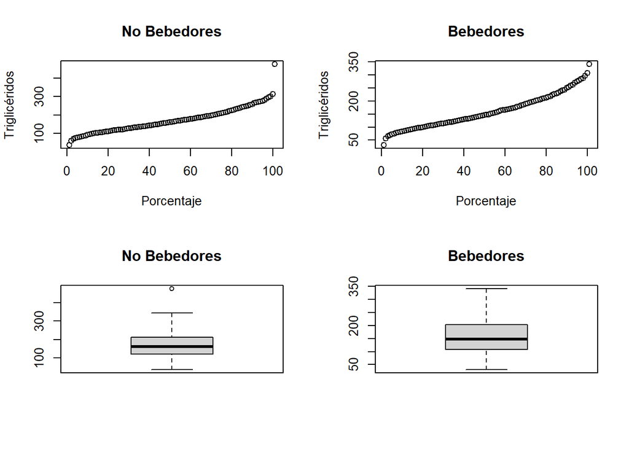

```r
par(mfrow=c(2, 2))
#quantile(data,prob=seq(0, 1, 1/X)) X es el numero de partes a dividir los datos
plot(quantile(drinkanyData.no$TG, prob=seq(0, 1, 1/100)),xlab = "Porcentaje" ,ylab = "Triglicéridos",main="No Bebedores")
plot(quantile(drinkanyData.yes$TG, prob=seq(0, 1, 1/100)),xlab = "Porcentaje" ,ylab = "Triglicéridos", main="Bebedores")
#los Boxplots son buenos para mostrar los cuartiles
boxplot(drinkanyData.no$TG, main="No Bebedores")
boxplot(drinkanyData.yes$TG,main="Bebedores")
```

De esta manera podemos observar cómo se distribuyen los datos y algunos valores muy alejados de los datos (outliers) ### La forma fácil R tiene una función que permite visualizar de forma fácil todos estos cálculos, summary() devuelve el valor más bajo, el valor más alto, el cuartil 1,2,3 (los valores que ocupan el 25%,50% y 75%) y la media.

```r
summary_yes<-summary(drinkanyData.yes$TG)
summary_no<-summary(drinkanyData.no$TG)
summary_d<-data.frame(c(summary_no),c(summary_yes))
summary_d
```

```
##         c.summary_no. c.summary_yes.
## Min.          36.0000        31.0000
## 1st Qu.      120.0000       108.0000
## Median       162.0000       147.0000
## Mean         169.5164       158.9304
## 3rd Qu.      212.0000       203.2500
## Max.         476.0000       341.0000
```

Summary tambien funciona en todos los datos de un dataframe

```r
summary(drinkanyData.yes)
```

```
##       HT                 age           raceth            nonwhite
##  Length:1020        Min.   :44.00   Length:1020        Length:1020
##  Class :character   1st Qu.:61.00   Class :character   Class :character
##  Mode  :character   Median :66.00   Mode  :character   Mode  :character
##                     Mean   :66.19
##                     3rd Qu.:72.00
##                     Max.   :79.00
##    smoking            drinkany           exercise           physact
##  Length:1020        Length:1020        Length:1020        Length:1020
##  Class :character   Class :character   Class :character   Class :character
##  Mode  :character   Mode  :character   Mode  :character   Mode  :character
##
##
##
##    globrat            poorfair            medcond         htnmeds
##  Length:1020        Length:1020        Min.   :0.0000   Length:1020
##  Class :character   Class :character   1st Qu.:0.0000   Class :character
##  Mode  :character   Mode  :character   Median :0.0000   Mode  :character
##                                        Mean   :0.3284
##                                        3rd Qu.:1.0000
##                                        Max.   :1.0000
##    statins            diabetes           dmpills            insulin
##  Length:1020        Length:1020        Length:1020        Length:1020
##  Class :character   Class :character   Class :character   Class :character
##  Mode  :character   Mode  :character   Mode  :character   Mode  :character
##
##
##
##      weight            BMI            waist             WHR
##  Min.   : 37.60   Min.   :15.49   Min.   : 57.50   Min.   :0.6330
##  1st Qu.: 61.95   1st Qu.:24.49   1st Qu.: 81.00   1st Qu.:0.8040
##  Median : 70.15   Median :27.20   Median : 89.00   Median :0.8570
##  Mean   : 71.86   Mean   :28.03   Mean   : 90.26   Mean   :0.8622
##  3rd Qu.: 79.50   3rd Qu.:31.02   3rd Qu.: 99.00   3rd Qu.:0.9130
##  Max.   :132.00   Max.   :54.13   Max.   :170.00   Max.   :1.1670
##     glucose         weight1            BMI1           waist1
##  Min.   : 56.0   Min.   : 37.70   Min.   :14.73   Min.   : 59.00
##  1st Qu.: 91.0   1st Qu.: 60.60   1st Qu.:24.04   1st Qu.: 80.15
##  Median : 98.0   Median : 69.90   Median :27.14   Median : 88.00
##  Mean   :106.5   Mean   : 71.18   Mean   :27.82   Mean   : 89.68
```

[output cut: 15 more lines]

```
##  Max.   :112.00   Max.   :341.0   Max.   :443.0   Max.   :340.0
##       HDL1             TG1             SBP             DBP
##  Min.   : 24.00   Min.   : 31.0   Min.   : 87.0   Min.   : 46.00
##  1st Qu.: 44.00   1st Qu.:115.0   1st Qu.:121.0   1st Qu.: 67.00
##  Median : 52.00   Median :152.0   Median :132.0   Median : 73.00
##  Mean   : 54.18   Mean   :167.9   Mean   :133.3   Mean   : 73.27
##  3rd Qu.: 62.00   3rd Qu.:206.0   3rd Qu.:144.0   3rd Qu.: 80.00
##  Max.   :124.00   Max.   :660.0   Max.   :197.0   Max.   :102.00
##      age10
##  Min.   :4.400
##  1st Qu.:6.100
##  Median :6.600
##  Mean   :6.619
##  3rd Qu.:7.200
##  Max.   :7.900
```

# Varianza y Desviación estándar

```r
varianza<-var(drinkanyData.yes$TG)
desEst<-sd(drinkanyData.yes$TG)
var_sd_yes<-c(var=varianza,des=desEst)

varianza<-var(drinkanyData.no$TG)
desEst<-sd(drinkanyData.no$TG)
var_sd_no<-c(var=varianza,des=desEst)

var_sd<-data.frame(var_sd_yes,var_sd_no)
var_sd
```

```
##     var_sd_yes  var_sd_no
## var 3981.03833 3937.07850
## des   63.09547   62.74614
```

# Correlación y covarianza

La covarianza es un valor que indica el grado de variación de 2 conjuntos de datos con respecto a su media y su versión normalizada es la correlación. R cuenta con una función para calcular la correlación y covarianza entre 2 conjuntos de datos, cor(). A continuación se correlacionó el índice de masa corporal, con el peso y Triglicéridos(TG).

```r
dtCorr<-data.frame(BMI=drinkanyData.yes$BMI,Weight=drinkanyData.yes$weight,TG=drinkanyData.yes$TG)
#Cov y Cor funcionan en un dataframe si todos los datos son numericos
cov(dtCorr)
```

```
##             BMI    Weight         TG
## BMI    27.00839  67.95556   59.60822
## Weight 67.95556 202.22127  147.70369
## TG     59.60822 147.70369 3981.03833
```

```r
#el parametro method permite cambiar entre la correlacion a calcular "pearson" (default), "kendall", or "spearman"
cor(dtCorr,method = "p")
```

```
##              BMI    Weight        TG
## BMI    1.0000000 0.9195222 0.1817852
## Weight 0.9195222 1.0000000 0.1646189
## TG     0.1817852 0.1646189 1.0000000
```

```r
cor(dtCorr,method = "s")
```

```
##              BMI    Weight        TG
## BMI    1.0000000 0.9106160 0.2111205
## Weight 0.9106160 1.0000000 0.1933754
## TG     0.2111205 0.1933754 1.0000000
```

```r
cor(dtCorr,method = "k")
```

```
##              BMI    Weight        TG
## BMI    1.0000000 0.7425660 0.1418646
## Weight 0.7425660 1.0000000 0.1305115
## TG     0.1418646 0.1305115 1.0000000
```

```r
#la funcion cor.test() tambien regresa el pvalue del calculo
```

Entre más cercano a 1 sea el valor absoluto de correlación, la relación entre los 2 conjuntos de datos será más fuerte la relación entre los datos. R también cuenta con una función para observar la correlación entre múltiples variables de un dataframa produciendo un diagrama de dispersión (scatterplot) por cada par de datos, pairs(),

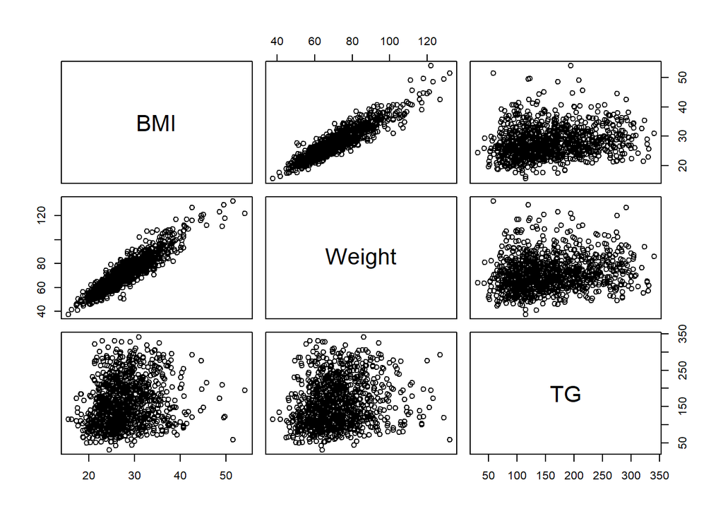

```r
pairs(dtCorr)
```

# Distribuciones de probabilidad

Permite generar simulaciones de datos con distintas distribuciones de probabilidad y cada una se identifica por un alias, las más importantes son: binomial(binom), Poisson(pois),normal(norm), exponencial(exp), t de Student(t),chi^2(chisq),Distribución F(f),uniforme(unif, etc para la lista completa help(Distributions).

Estas funciones son muy útiles para generar grandes conjuntos de datos aleatorios con una distribución de nuestro interés y compararlos con nuestros datos o usarlos como un grupo de control.

### Normal

Para mas informacion de las funciones [norm()](https://r-coder.com/distribucion-normal-r/) Utilicemos la media y la desviación estándar de los datos de Bebedores para generar una distribución normal y compararlas.

```r
#distribucion normal
set.seed(10)
DatosTG<-drinkanyData.yes$TG
MediaTG<-summary_d$c.summary_yes[4]
SdTG<-var_sd$var_sd_yes[2]
#Generamos un arreglo de longitud n con una distribucion normal con una media (mean) y desviacion estandar (sd)
Dnormal<-rnorm(n=1020,mean = MediaTG,sd = SdTG)
#qnorm calcula el cuantil p, en este caso calcula los cuartiles
QuarNorm<-qnorm(p=seq(0, 1, 1/4),mean = MediaTG,sd = SdTG)
#pnorm calcula la probabilidad de que una variable aleatoria sea menor que q
Quar_DD<-quantile(drinkanyData.yes$TG, prob=seq(0, 1, 1/4))
ProbNorm_datos<-pnorm(q=Quar_DD,mean = MediaTG,sd = SdTG)
#pnorm al ingresar quantiles generados con los mismos parametros como resultado el valor p de qnorm
ProbNorm_normal<-pnorm(q=QuarNorm,mean = MediaTG,sd = SdTG)
#comparemos con nuestros datos

dt_norm_Vs_Datos<-data.frame(Quar_DD,QuarNorm,ProbNorm_normal,ProbNorm_datos)
dt_norm_Vs_Datos
```

```
##      Quar_DD QuarNorm ProbNorm_normal ProbNorm_datos
## 0%     31.00     -Inf            0.00     0.02130215
## 25%   108.00 116.3731            0.25     0.20977687
## 50%   147.00 158.9304            0.50     0.42501319
## 75%   203.25 201.4876            0.75     0.75879180
## 100%  341.00      Inf            1.00     0.99804679
```

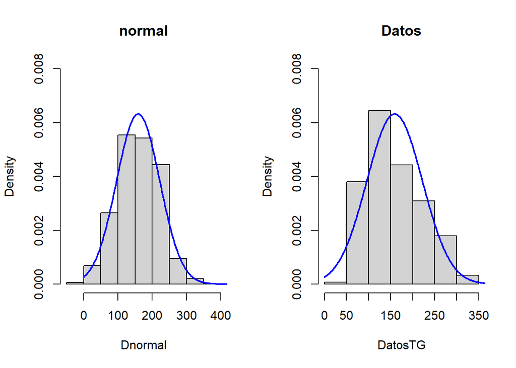

```r
#calcula la funcion de densiada
x<-seq(0, 1020, length = 1020)
distNorm<-dnorm(x=x,mean = MediaTG,sd = SdTG)
#imprimamos los datos
par(mfrow=c(1, 2))
hist(Dnormal,main = "normal",freq = F,ylim =  c(0,0.008))
lines(x,distNorm,col = "blue", lty = 1, lwd = 2)
hist(DatosTG,main = "Datos",freq = F,ylim =  c(0,0.008))
lines(x,distNorm,col = "blue", lty = 1, lwd = 2)
```

Estos gráficos nos muestran las distribuciones de los datos reales y los datos generados por rnorm() junto con una curva de densidad normal. A continuación se muestran algunas distribuciones.

### Exponencial y uniforme

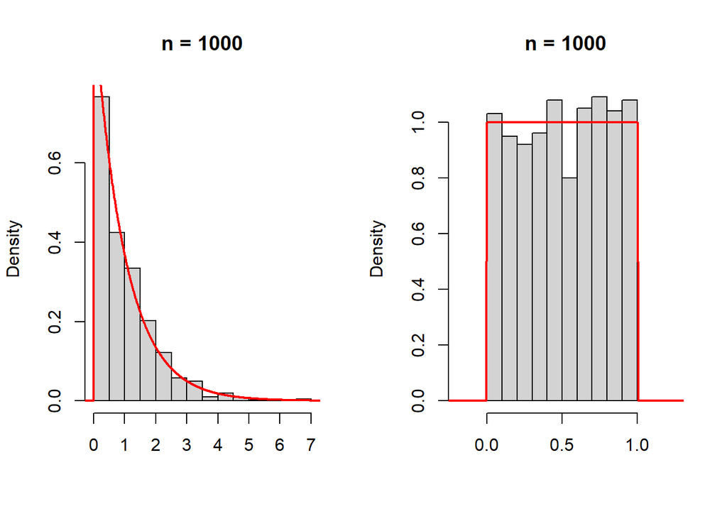

```r
x <- seq(-10, 10, 0.01)
set.seed(10)
par(mfrow=c(1, 2))
#Exponencial
hist(rexp(1000), main = "n = 1000",
     xlab = "", prob = TRUE)
lines(x, dexp(x), col = "red", lwd = 2)
#Uniforme
hist(runif(1000), main = "n = 1000", xlim = c(-0.2, 1.25),
     xlab = "", prob = TRUE)
lines(x, dunif(x), col = "red", lwd = 2)
```

### Poisson y Binomial

Para más formación de estas funciones en R [Poisson](https://r-coder.com/distribucion-poisson-r/) y [Binomial](https://r-coder.com/distribucion-binomial-r/)

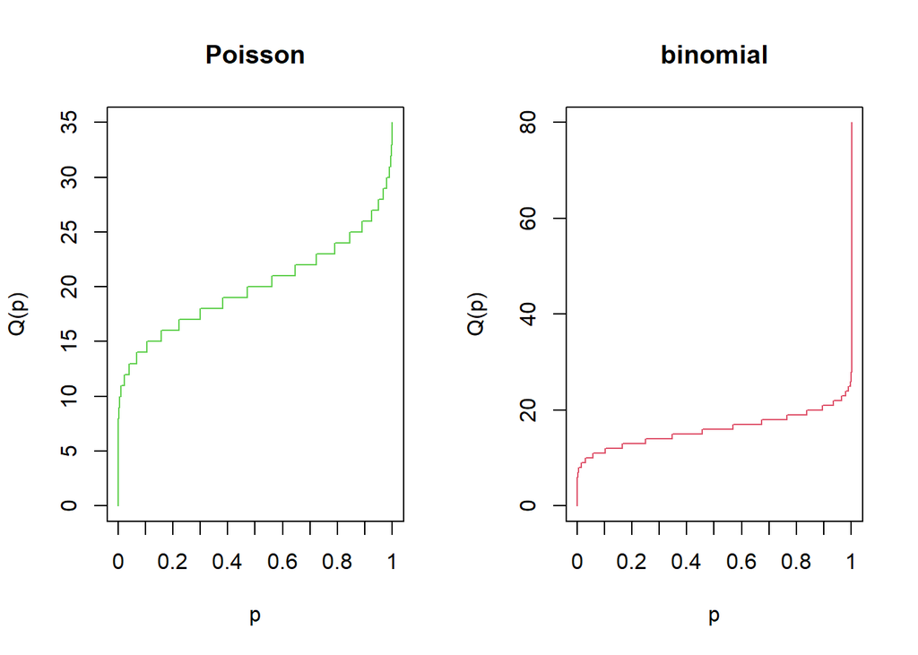

```r
par(mfrow=c(1, 2))
x<-seq(0, 1, 0.001)
#la función cuantil de la distribución de Poisson
plot(qpois(x, lambda = 20),
     main = "Poisson",
     ylab = "Q(p)", xlab = "p",
     type = "s", col = 3, xaxt = "n")

axis(1, labels = seq(0, 1, 0.1), at = 0:10 * 100)

# la función cuantil binomia size = 80, prob = 0.2
plot(qbinom(x, size = 80, prob = 0.2),
     main = "binomial",
     ylab = "Q(p)", xlab = "p",
     type = "s", col = 2, xaxt = "n")
axis(1, labels = seq(0, 1, 0.1), at = 0:10 * 100)
```